# (New) Variable Importance Summary, Natural Scale

Si Cheng

2022-02-17

## Approach 2: Changing predictor value from median

We consider an alternative approach proposed during the group meeting on Oct 11. The idea was to fix each predictor at their median (one at a time), and see how the predicted values change after increasing/decreasing them by a certain magnitude.

The model was trained with all 309 locations from the mobile monitoring data, and evaluated at each of these locations in a leave-one-out manner. The key idea was that we use the same mean model, but incorporate a new covariance part when looking at each location. We compare the predicted values when each predictor takes their 25%, 50% and 75% quantile.

### UFP

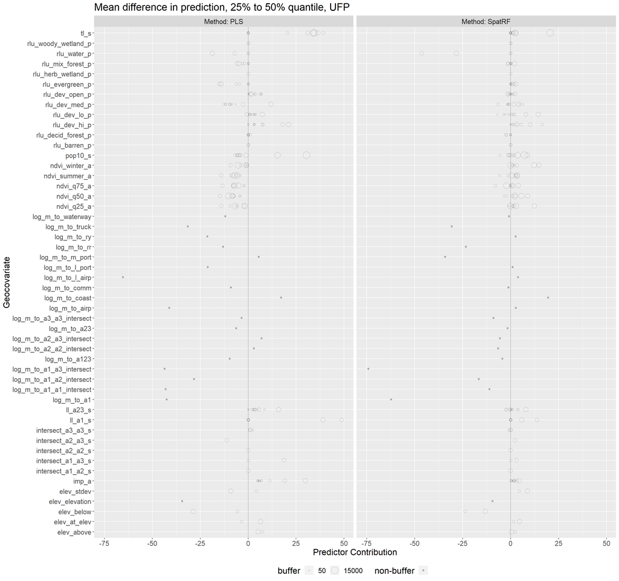

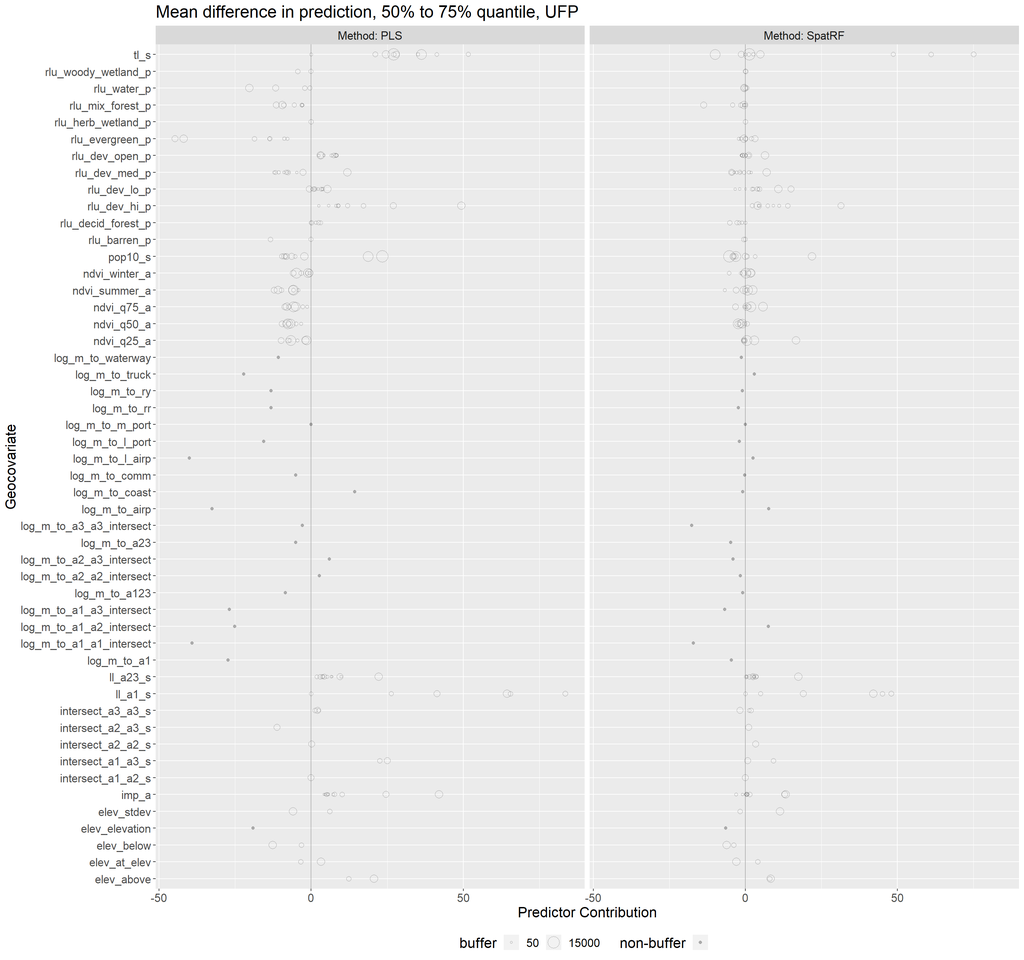

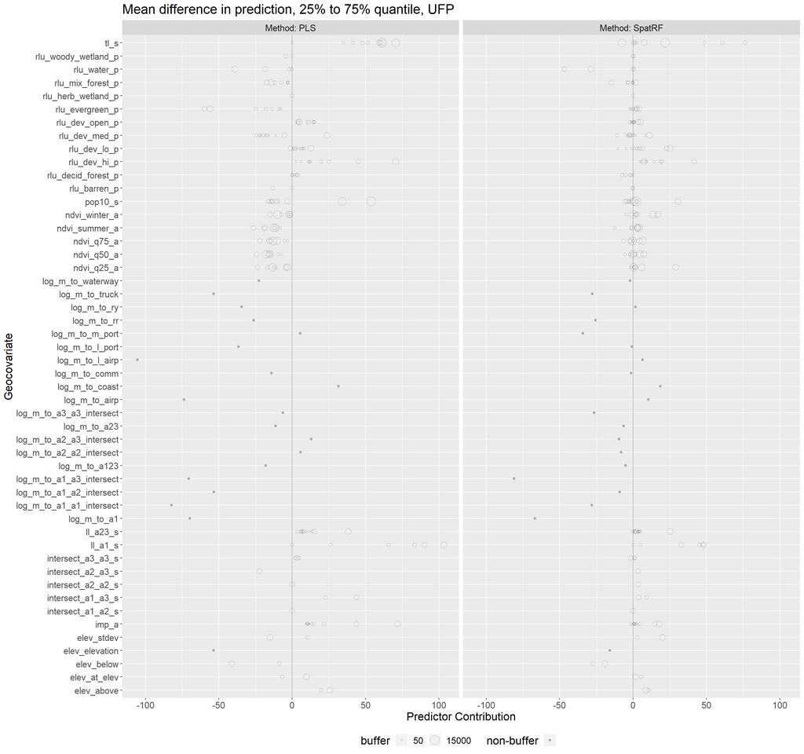

The greatest differences between UK-PLS and SpatRF:

25% to 50% quantile, UFP

| PLS | SpatRF | abs(difference) | Variable |
| --- | --- | --- | --- |
| -7.014867 | -46.304381 | 39.28951 | rlu_water_p03000 |
| 39.289904 | 1.369006 | 37.92090 | tl_s01500 |
| -41.141477 | 2.709100 | 43.85058 | log_m_to_airp |
| -65.340689 | 3.927758 | 69.26845 | log_m_to_l_airp |
| 5.545609 | -34.188253 | 39.73386 | log_m_to_m_port |

50% to 75% quantile, UFP

| PLS | SpatRF | abs(difference) | Variable |
| --- | --- | --- | --- |
| -44.73911 | 3.238014 | 47.97712 | rlu_evergreen_p03000 |
| 49.40347 | 4.076781 | 45.32669 | rlu_dev_hi_p05000 |
| 21.05440 | 75.054279 | 53.99988 | tl_s01500 |
| 36.27754 | -9.905623 | 46.18317 | tl_s10000 |
| -40.09206 | 2.516274 | 42.60834 | log_m_to_l_airp |

25% to 75% quantile, UFP

| PLS | SpatRF | abs(difference) | Variable |
| --- | --- | --- | --- |
| -59.71815 | 4.323656 | 64.04181 | rlu_evergreen_p03000 |
| 70.46618 | 7.296365 | 63.16982 | rlu_dev_hi_p05000 |
| 70.32823 | -7.695912 | 78.02414 | tl_s10000 |
| -73.74660 | 10.423410 | 84.17001 | log_m_to_airp |
| -105.43275 | 6.444032 | 111.87678 | log_m_to_l_airp |

Results on predictors corresponding to the greatest differences did not greatly differ from our previous version of variable importance evaluated with cohort data. Again, it seems that SpatRF is not capturing the impact of airport on UFP concentration, which was likely explained by other predictors instead.

It is also worth noting that (as in the last version) the sign of some predictor effects from SpatRF are different from UK-PLS (as well as our common sense), though their magnitude is often not large (see, e.g. distance to large airports, length of truck routes with buffer size 10000). Again, this is likely because such effects are captured by other predictors.

**Cleaned variable importance plot with top 10 differences**

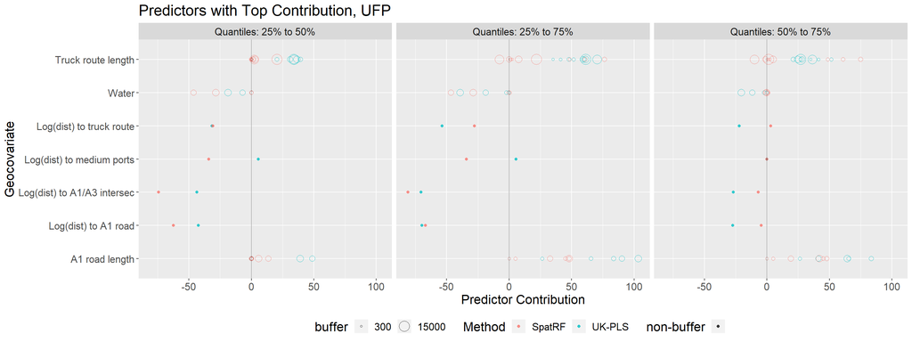

### BC

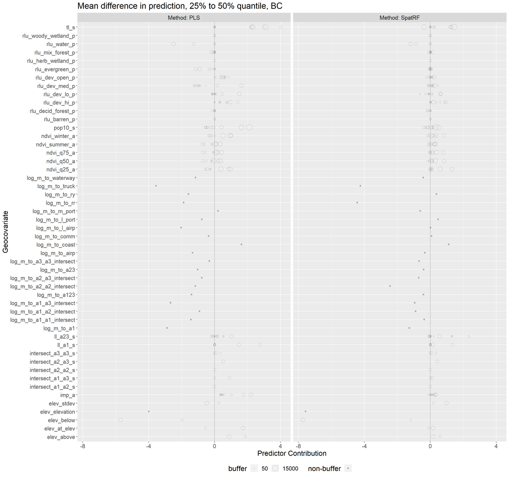

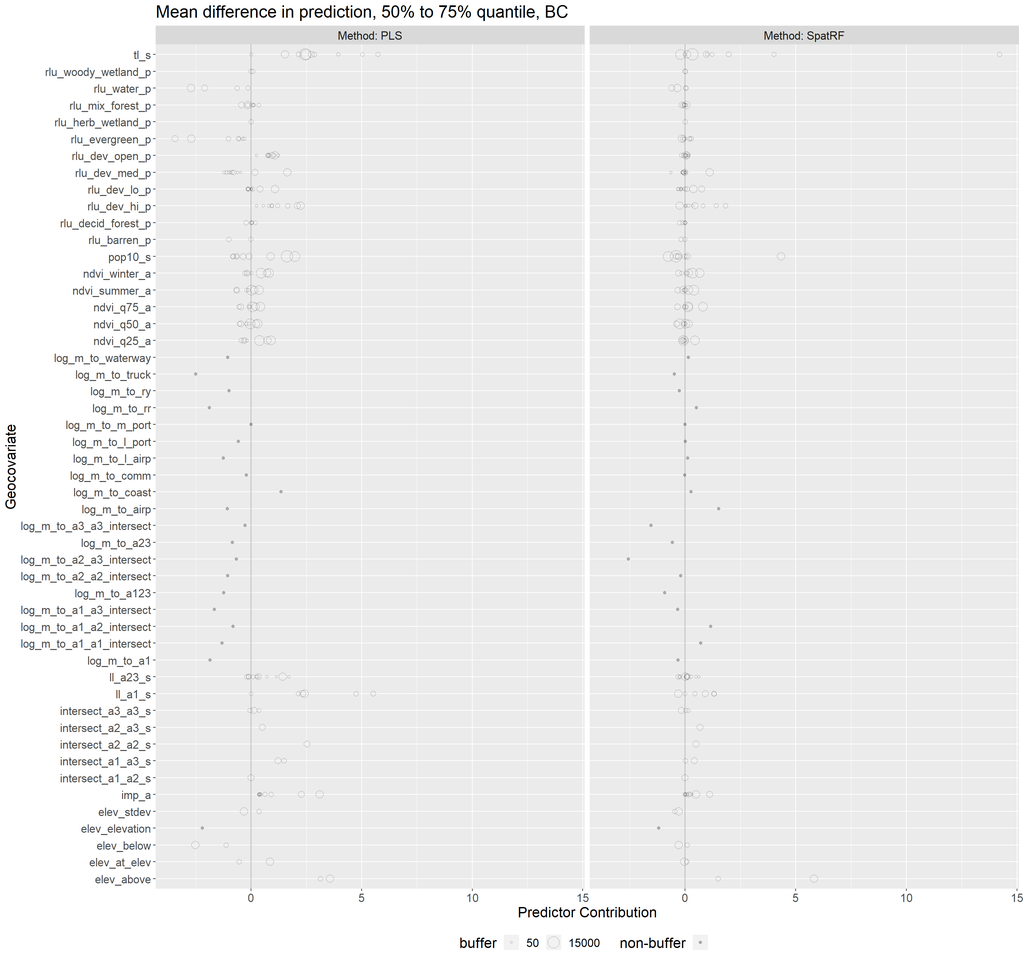

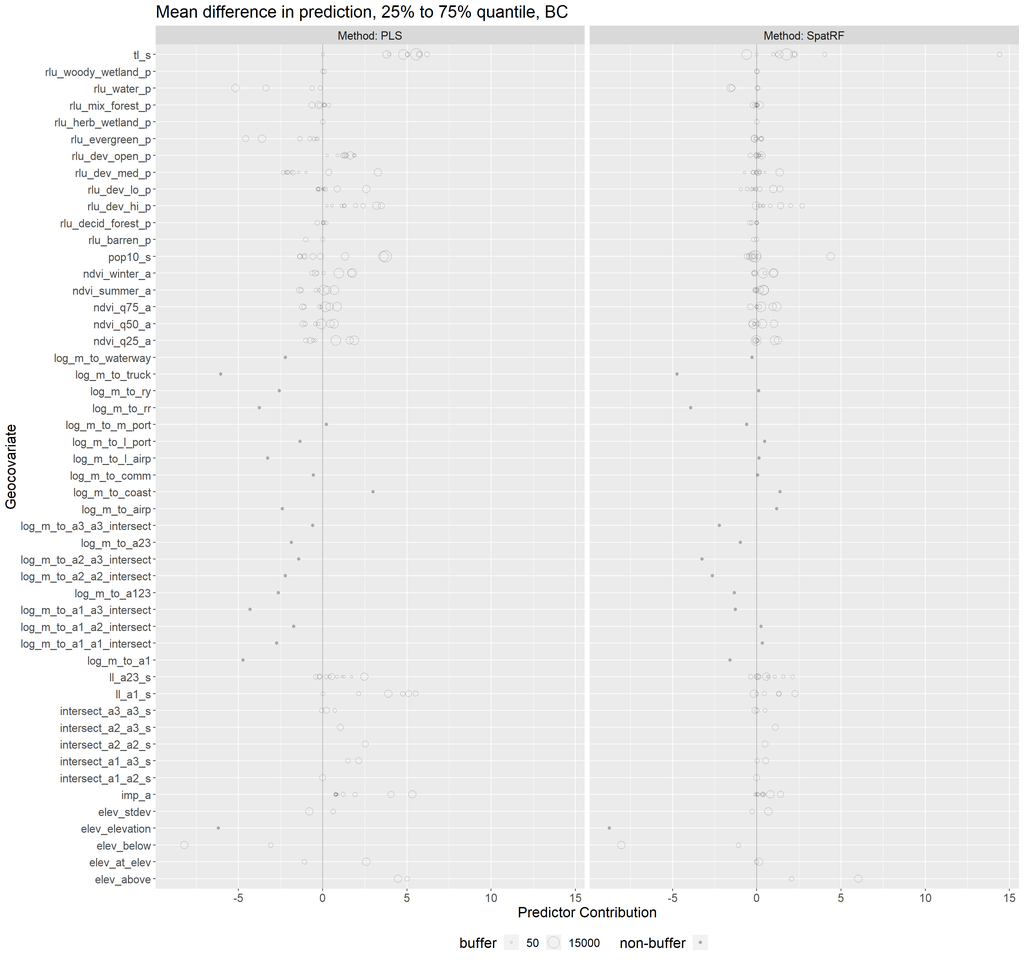

The greatest differences between UK-PLS and SpatRF:

25% to 50% quantile, BC

| PLS | SpatRF | abs(difference) | Variable |
| --- | --- | --- | --- |
| -3.984444 | -7.5729585 | 3.588515 | elev_elevation |
| 4.033995 | 0.2646756 | 3.769319 | tl_s01500 |
| 2.319779 | -0.3865734 | 2.706352 | tl_s10000 |
| 0.093438 | 2.3357365 | 2.242298 | ll_a23_s00500 |
| -1.874389 | -4.4395815 | 2.565193 | log_m_to_rr |

50% to 75% quantile, BC

| PLS | SpatRF | abs(difference) | Variable |
| --- | --- | --- | --- |
| 4.7530342 | 1.312206 | 3.440828 | ll_a1_s01000 |
| 5.5292645 | 1.307038 | 4.222227 | ll_a1_s01500 |
| 5.0322456 | 1.218991 | 3.813255 | tl_s00500 |
| 2.8710870 | 14.208649 | 11.337562 | tl_s01000 |
| 0.8930077 | 4.332997 | 3.439989 | pop10_s05000 |

25% to 75% quantile, BC

| PLS | SpatRF | abs(difference) | Variable |
| --- | --- | --- | --- |
| 5.327110 | 0.8096291 | 4.517481 | imp_a05000 |
| 5.529265 | 1.3070377 | 4.222227 | ll_a1_s01500 |
| -4.577514 | -0.1246522 | 4.452862 | rlu_evergreen_p03000 |
| 5.037401 | 14.4071285 | 9.369727 | tl_s01000 |
| 4.790251 | -0.6011505 | 5.391402 | tl_s10000 |

**Cleaned variable importance plot with top 10 differences**

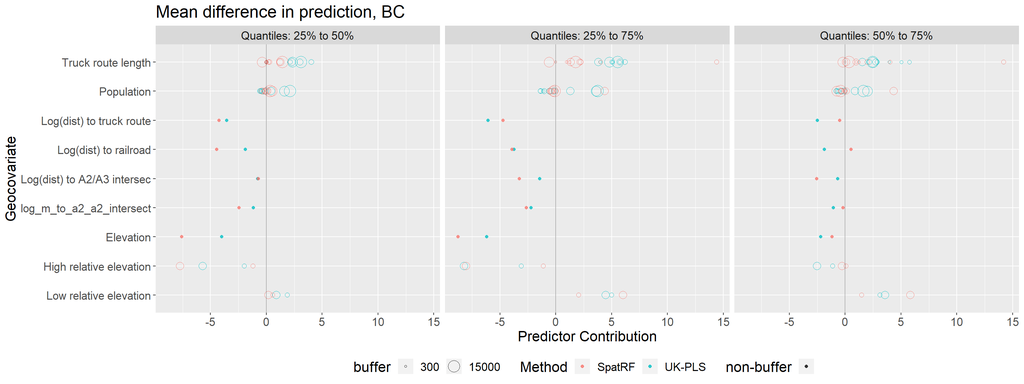

### NO2

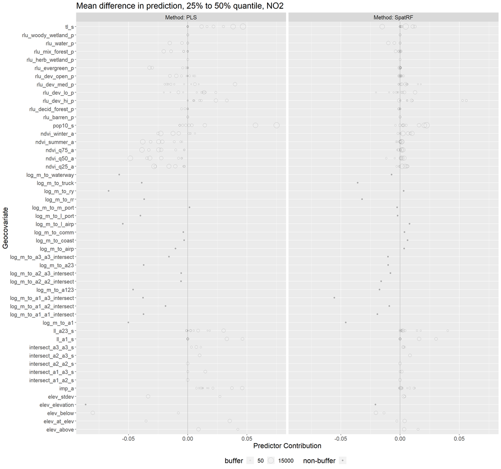

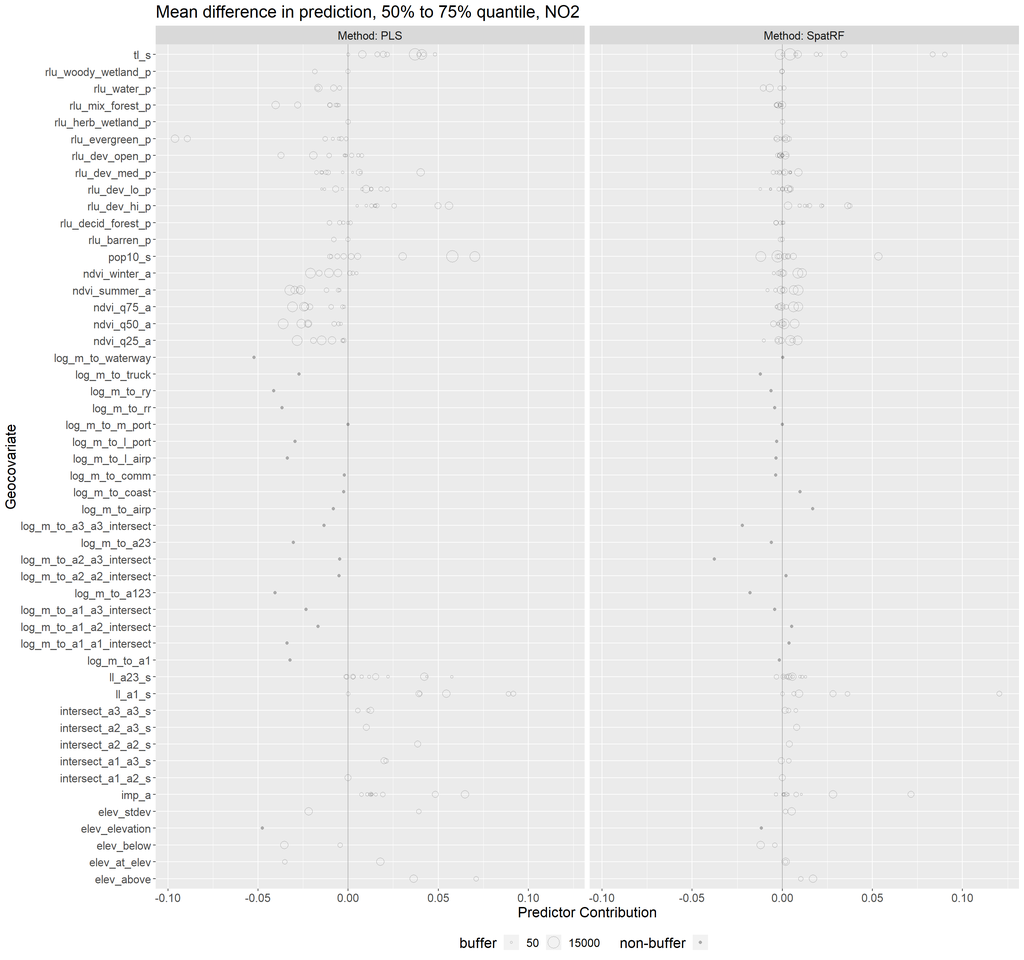

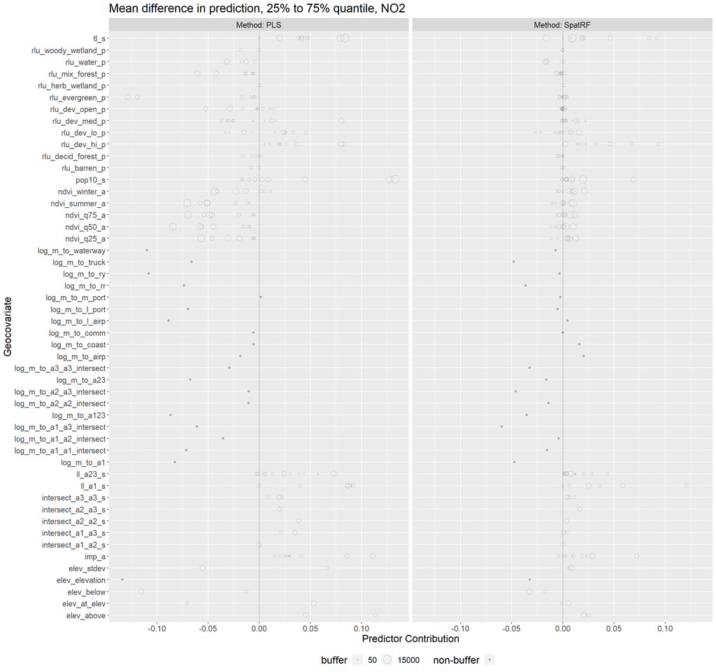

The greatest differences between UK-PLS and SpatRF:

25% to 50% quantile, NO2

| PLS | SpatRF | abs(difference) | Variable |
| --- | --- | --- | --- |
| -0.0862225 | -0.0208342 | 0.0653884 | elev_elevation |
| -0.0801841 | -0.0204628 | 0.0597213 | elev_5k_below |
| 0.0383319 | -0.0152181 | 0.0535500 | tl_s10000 |
| -0.0548662 | 0.0079426 | 0.0628088 | log_m_to_l_airp |
| -0.0668182 | 0.0029376 | 0.0697558 | log_m_to_ry |

50% to 75% quantile, NO2

| PLS | SpatRF | abs(difference) | Variable |
| --- | --- | --- | --- |
| -0.0892300 | -0.0028940 | 0.0863360 | rlu_evergreen_p03000 |
| -0.0960365 | 0.0020387 | 0.0980752 | rlu_evergreen_p05000 |
| 0.0215198 | 0.0900717 | 0.0685519 | tl_s01000 |
| 0.0161909 | 0.0835155 | 0.0673246 | tl_s01500 |
| 0.0701436 | -0.0119130 | 0.0820566 | pop10_s10000 |

25% to 75% quantile, NO2

| PLS | SpatRF | abs(difference) | Variable |
| --- | --- | --- | --- |
| -0.1191759 | -0.0030274 | 0.1161485 | rlu_evergreen_p03000 |
| -0.1282833 | 0.0017935 | 0.1300768 | rlu_evergreen_p05000 |
| 0.1273488 | 0.0084331 | 0.1189157 | pop10_s10000 |
| 0.1330042 | 0.0197889 | 0.1132153 | pop10_s15000 |
| -0.1081408 | -0.0032304 | 0.1049105 | log_m_to_ry |

**Cleaned variable importance plot with top 10 differences**

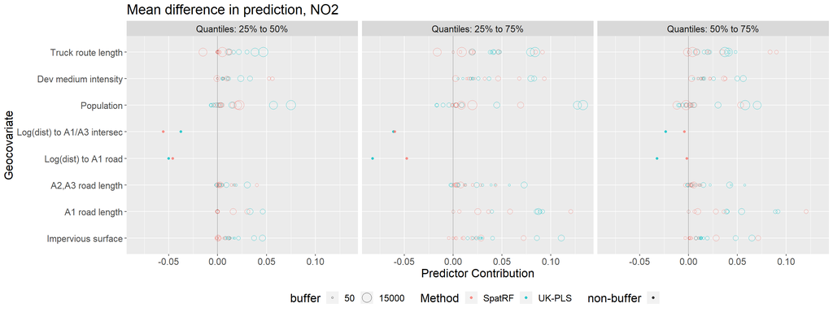

### CO2

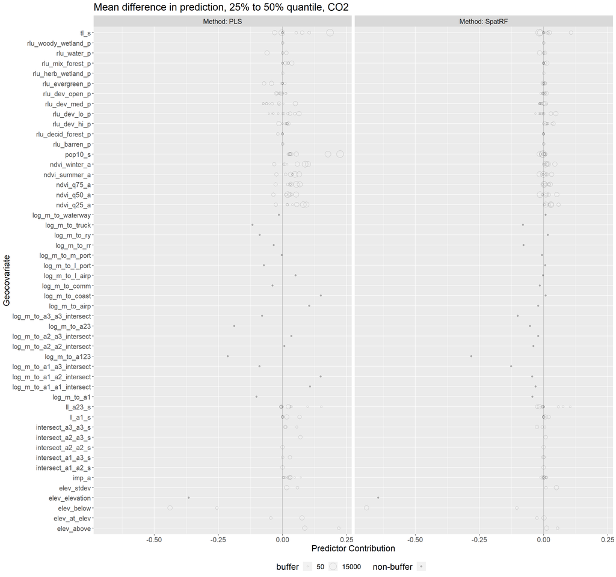

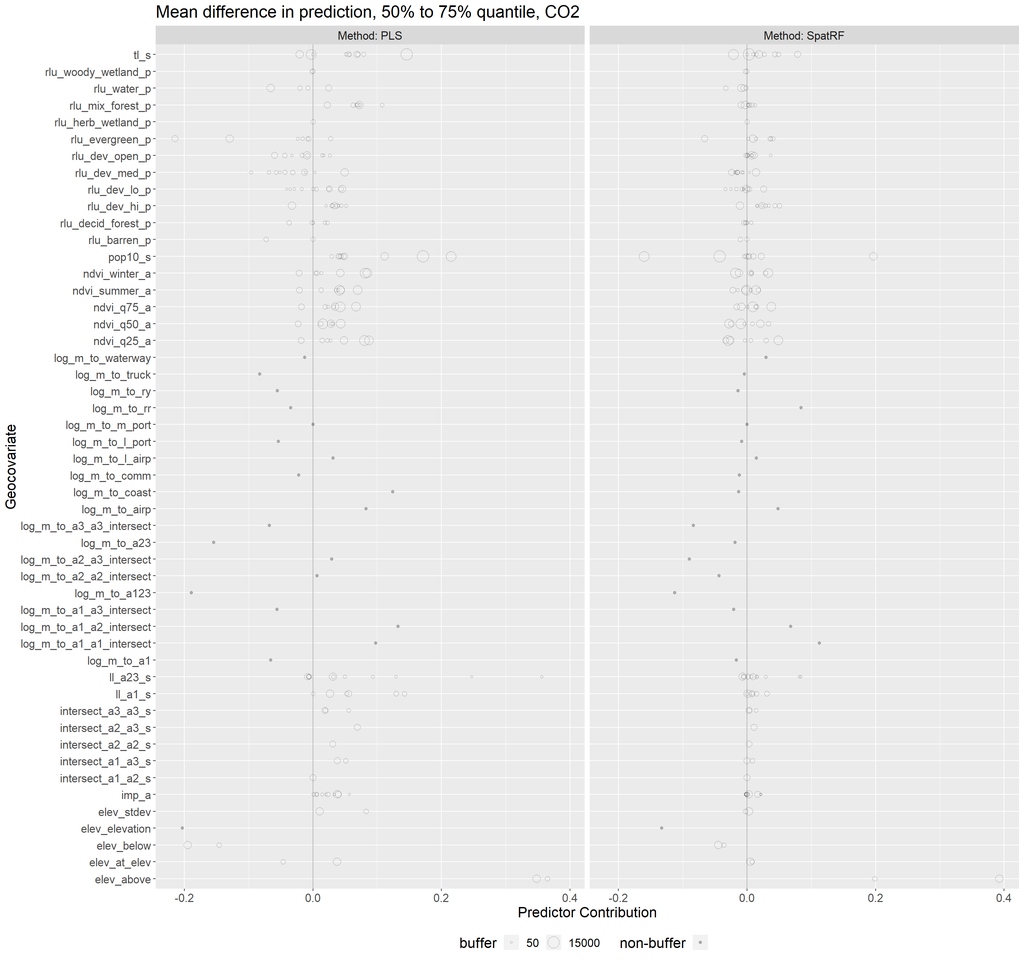

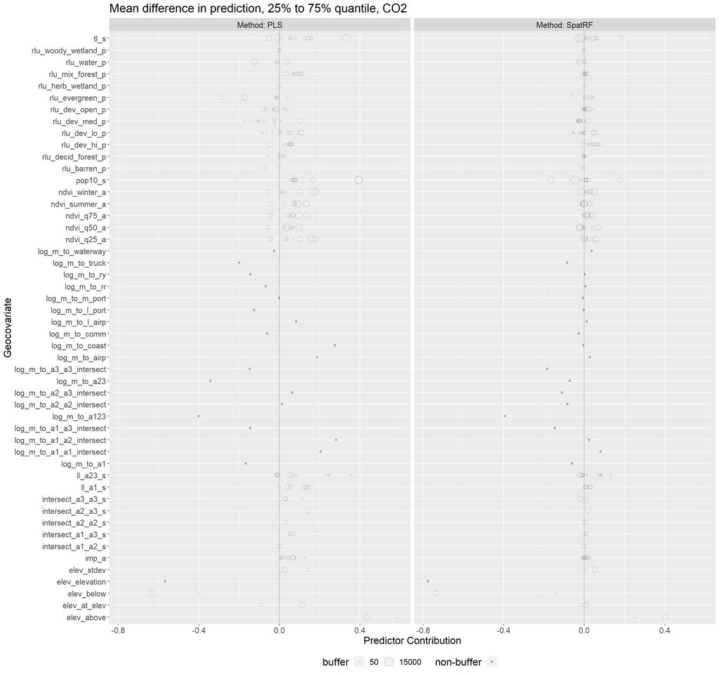

The greatest differences between UK-PLS and SpatRF:

25% to 50% quantile, CO2

| PLS | SpatRF | abs(difference) | Variable |
| --- | --- | --- | --- |
| -0.3654170 | -0.6446184 | 0.2792013 | elev_elevation |
| -0.4382650 | -0.6902292 | 0.2519642 | elev_5k_below |
| 0.1849462 | -0.0170881 | 0.2020344 | tl_s15000 |
| 0.2241563 | -0.0029307 | 0.2270870 | pop10_s15000 |
| 0.1482723 | -0.0443958 | 0.1926680 | log_m_to_a1_a2_intersect |

50% to 75% quantile, CO2

| PLS | SpatRF | abs(difference) | Variable |
| --- | --- | --- | --- |
| 0.3646759 | 0.1986052 | 0.1660707 | elev_1k_above |
| 0.2151728 | -0.1603605 | 0.3755334 | pop10_s10000 |
| 0.1715183 | -0.0422948 | 0.2138131 | pop10_s15000 |
| 0.2472497 | 0.0156248 | 0.2316250 | ll_a23_s00050 |
| 0.3561489 | 0.0814253 | 0.2747236 | ll_a23_s00100 |

25% to 75% quantile, CO2

| PLS | SpatRF | abs(difference) | Variable |
| --- | --- | --- | --- |
| 0.5833327 | 0.2519785 | 0.3313542 | elev_1k_above |
| 0.3311473 | -0.0141122 | 0.3452596 | tl_s15000 |
| 0.3918512 | -0.1663065 | 0.5581577 | pop10_s10000 |
| 0.3956746 | -0.0452255 | 0.4409001 | pop10_s15000 |
| 0.2738954 | -0.0053291 | 0.2792246 | log_m_to_coast |

**Cleaned variable importance plot with top 10 differences**

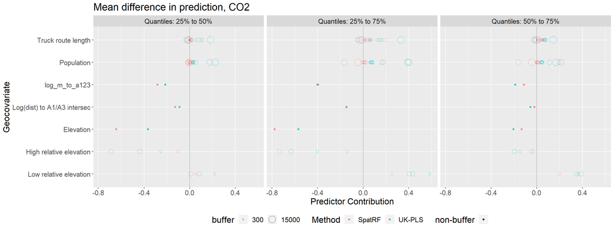

### PM2.5

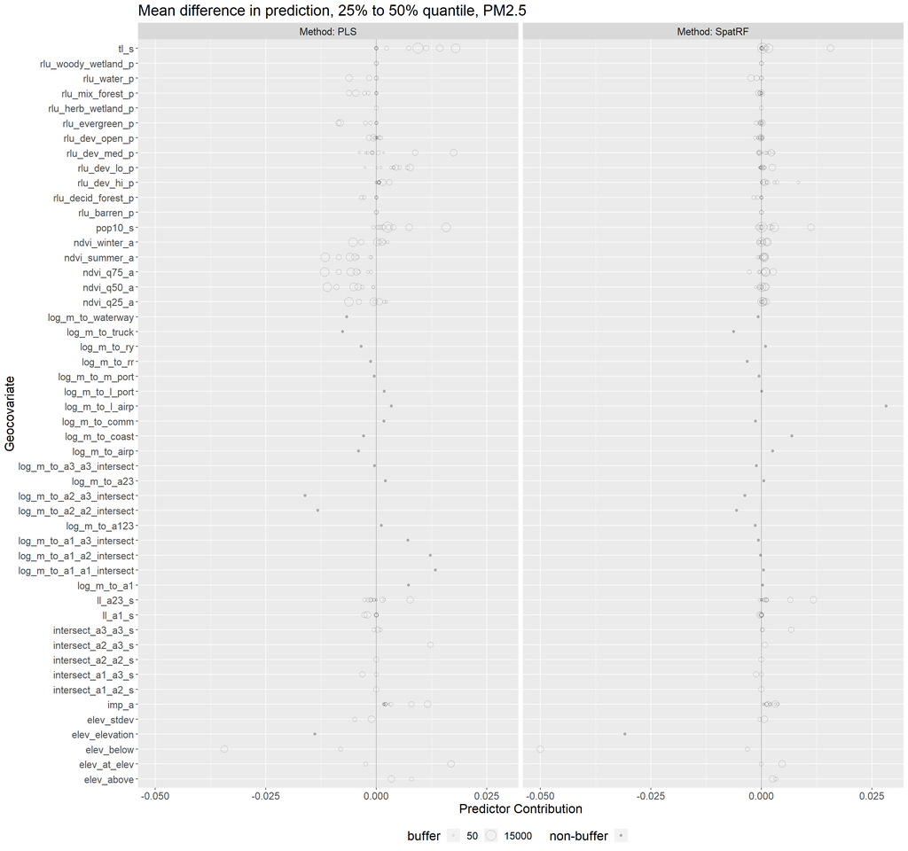

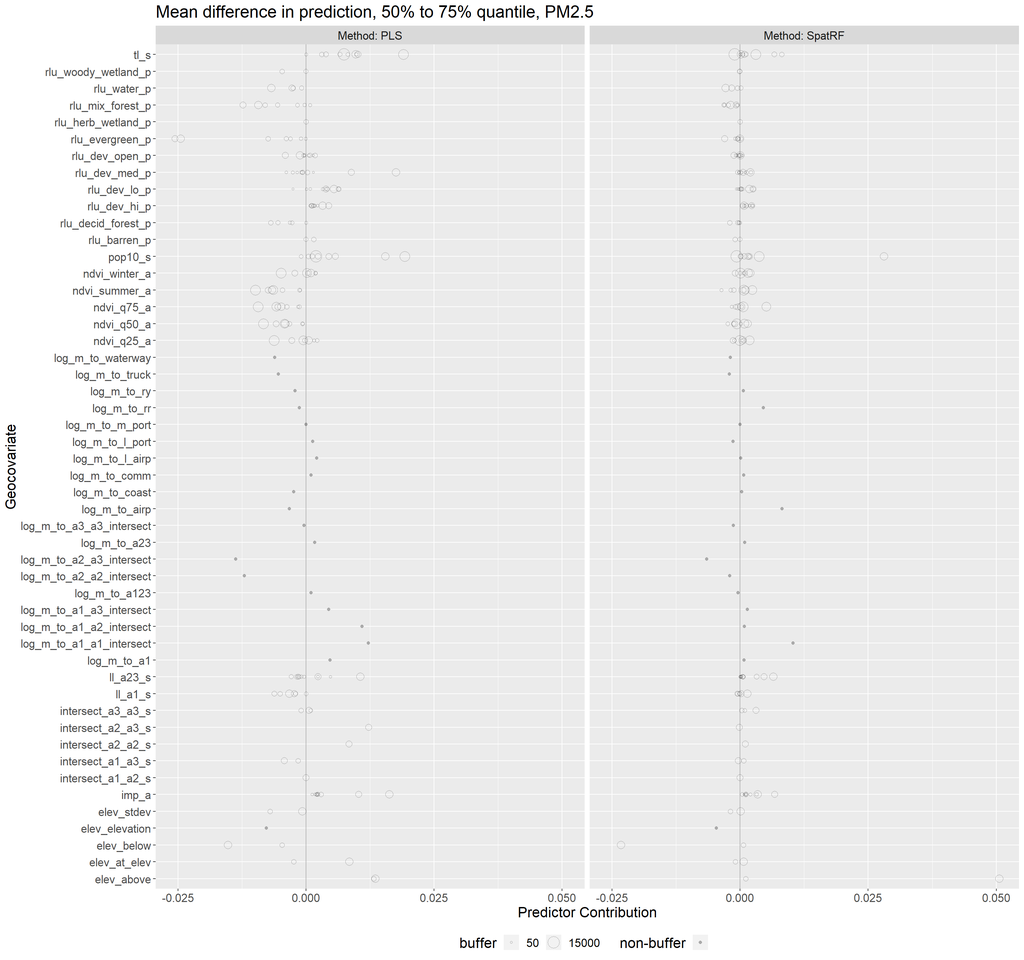

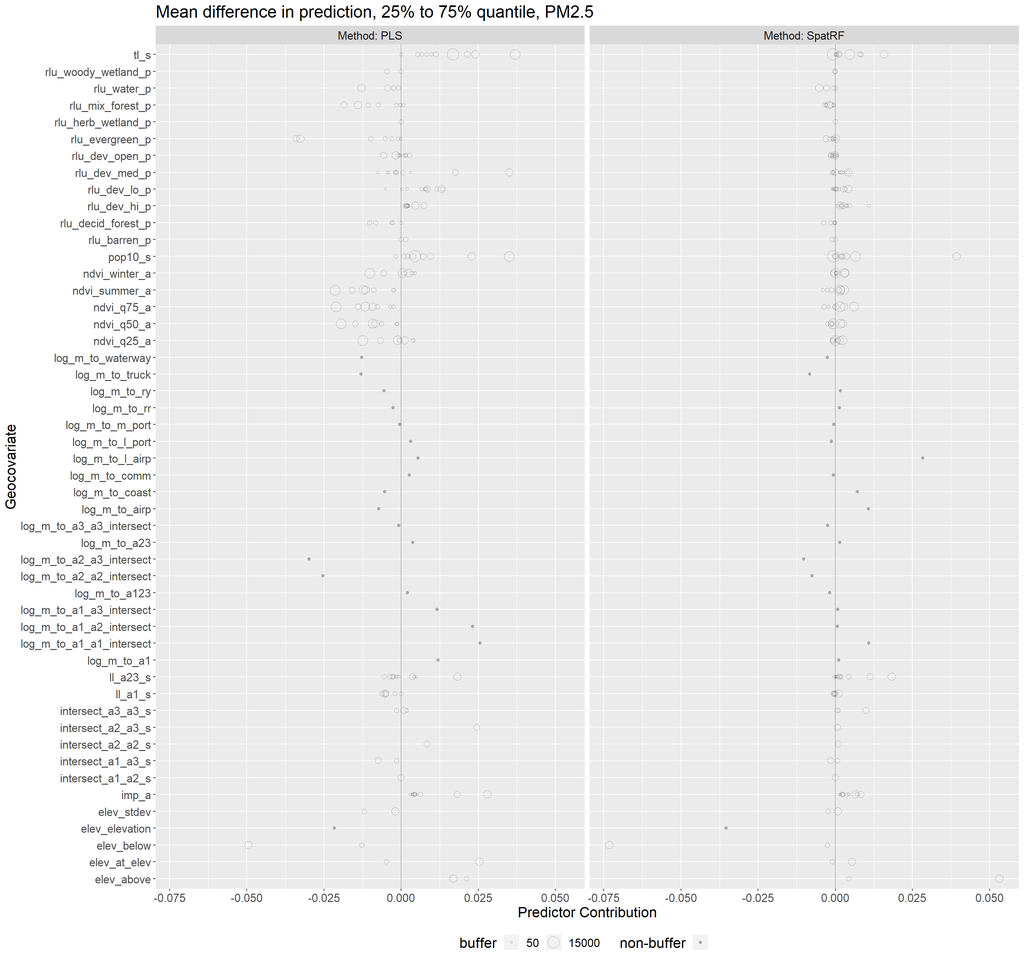

The greatest differences between UK-PLS and SpatRF:

25% to 50% quantile, PM2.5

| PLS | SpatRF | abs(difference) | Variable |
| --- | --- | --- | --- |
| -0.0139355 | -0.0308343 | 0.0168988 | elev_elevation |
| -0.0343584 | -0.0500004 | 0.0156420 | elev_5k_below |
| 0.0175018 | 0.0022365 | 0.0152653 | rlu_dev_med_p05000 |
| 0.0178878 | 0.0016520 | 0.0162358 | tl_s10000 |
| 0.0033900 | 0.0282518 | 0.0248618 | log_m_to_l_airp |

50% to 75% quantile, PM2.5

| PLS | SpatRF | abs(difference) | Variable |
| --- | --- | --- | --- |
| 0.0135530 | 0.0506293 | 0.0370763 | elev_5k_above |
| -0.0255510 | -0.0030345 | 0.0225165 | rlu_evergreen_p03000 |
| -0.0244623 | -0.0000043 | 0.0244580 | rlu_evergreen_p05000 |
| 0.0190386 | 0.0030294 | 0.0160092 | tl_s10000 |
| 0.0192475 | 0.0036794 | 0.0155681 | pop10_s10000 |

25% to 75% quantile, PM2.5

| PLS | SpatRF | abs(difference) | Variable |
| --- | --- | --- | --- |
| 0.0169347 | 0.0532137 | 0.0362791 | elev_5k_above |
| -0.0341011 | -0.0030092 | 0.0310919 | rlu_evergreen_p03000 |
| 0.0350736 | 0.0042664 | 0.0308072 | rlu_dev_med_p05000 |
| -0.0326467 | 0.0001526 | 0.0327993 | rlu_evergreen_p05000 |
| 0.0369263 | 0.0046814 | 0.0322450 | tl_s10000 |

**Cleaned variable importance plot with top 10 differences**

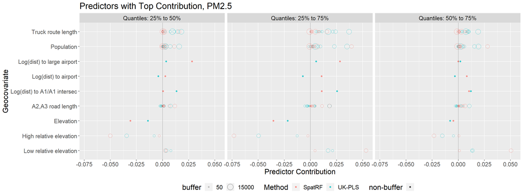